# Production and Operations Management - BA12A, Bataan Assignment

Del Rosario, Katherine Michelle & Santiago, Katrina

28 November 2017

## Facility Visits: Bataan Free-Port Zone

**Guang Qiang Manufacturing Corp.**

Originally a China-based company, Guang Qiang Manufacturing Corp. makes mold out of metal, their factory located at Mariveles, Bataan. Its purpose is for the labels being used for international brands such as Coach, MK and Kate Spade. They produce ten thousand (10000) units per year, according to the general manager, Sir Simon. The process involved in making the metal molds are as follows:

1. Cutting. This is where they cut the steel by using 32 mm or 36 mm of steel to the desired length they need. Cutting the cardboard and metal is to create shapes that will help cut raw materials such as leather used in internationally-branded bags.
2. Molding. With the use of the bending machine, this steel is now being shaped and they have this guide made out of thin cardboard with sizes on them and has an allowance of one inch on all sides which were given to them by their clients. The employee used his foot to control the machine.
3. Welding. In this step, metal on metal is being done wherein they are merged together. With the help of a torch, the metal being merged onto the base is soft enough to melt, but only to an extent similar to the basic gluing.
4. Grinding. This step is only for those mold with excess edges/blades by refining them to create a smooth edge . This prevents employees or users from having injuries and possibly creating unnecessary damage to the raw materials.
5. Quality Check. Inspection from the supervisors are needed for this step in order for the molds to be accepted. A set of standards are made to follow. This is to make sure that their product not only exceeds their expectations but the client???s as well. The better the mold works, the greater the customer loyalty.
6. Distribution. Once the molds passed quality checking and the set of standards given, they can now be packaged and sent via truck delivery to the clients where it will be used in their factory (e.g FCF Manufacturing). Due to reasons unidentified by their client, FCF has mentioned that they asked Guang Qiang to move their factory here in the Philippines. An assumption is made based on labor costs and cargo shipping that may be too risky for the client.

According to Mr. Simon, the hiring process is dependent on their post for hire. Usually, their normal post does not only refer to the direct labor, they also need someone who knows how to use the computer. This may be because the manager needs someone who is technology-wise to handle client orders, complaints, programming needs, research & development, possible hackers, communications, and more. He said that a background is not needed for creating the molds so long as they are willing to learn. Of course, face to face interviews are mandatory to be able to understand their personality better. Their supervisors will take them under their wing and train them for days on how to use the equipment properly. When asked about outcomes that are not up to quality standards, Mr. Simon clearly stated what he would do. He said that he would not put fault on the employee. Rather, he will look for their supervisor and give them a warning. Another one would lead to termination. Intrigued, we asked why.

“The employee just follows. It is their responsibility to make sure that the instructions are clear to them,”" he said with conviction.

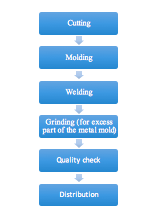

**MEDTECS**

MEDTECS is a company that is involved in selling wholesale and manufacturing clothing located in Bataan Economic Zone, Mariveles, Bataan. Named as MEDTECS because according to the supervisor from the dyeing department, the company supply???s the hospital bed sheets and work wear. Most of their clients are from Manila. It???s a company that manufactures various high-quality fabrics used mostly by groups in the medical field such as hospitals and clinics.

The 3-main process of MEDTECS are Weaving, Dyeing and Garments. In the weaving process, warping materials were imported from Taiwan. Before turning it into a fabric, the person in charge of purchasing the raw materials order batches of spools of threads that will then be attached to a display-like stand that is more than 5 feet wide. Each spool has its own place. These threads are then hooked to a very large spinning cylinder-type machine. As it spins, there is a quota on the thread count. After reaching the goal, they cut off the excess. The ones needed are passed on to the next station of workers. They used a hook and headwire to put threads together and pass it on to the next person in charge.

The dyeing process: 1. Spread. This is the preparation process to distribute in each overflow or in the jigger machine process. The overflow is used for bleaching/disperse dyeing & reactive dyeing process. 2. Jigger #5, Jigger #6, Jigger #9 and Jigger #10. For the cotton side vat dyeing for any blend cotton or 100% fabric. 3. Spindry. This process is where the excess is being removed. 4. Scutcher. In preparation for heat setting, this process spreads out the fabric. 5. Stenter. To get the required width, weight and the finishing touch of the fabric and some application of special chemical, this process is the drying and heat setting to get those required things. 6. Inspection. The final process includes checking the quality of the fabric if all the requirements needed is entirely applied like the correct color shading on visual and data reading, correct width, weight, the hand feeling and other quality concerns that might arise. a. Peaching. A special process for sanding to make the fabric feeling smoother but for selected product only. b. Winding. A packaging process wherein fabric is for long fold. c. Double Folding. A packaging process wherein fabric is for double fold.

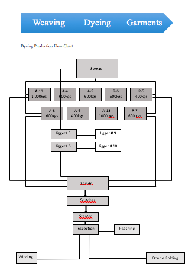

**FCF Manufacturing**

A company in Mariveles, Bataan that manufactures Coach products. It is a leading manufacturer of fashionable bags for export. It has around 1003 manpower and 48 production lines. Produces 250-300 of bags per line per day. The company has In-line-controllers who are in charge in the production of bags per line. The processes involved are: 1) Receiving of raw materials. Materials like leather should be store 65 degrees and below to avoid mold forming. 2) Inbound checking its part of coach standards. Supply line process are the following: 3) Cutting. This is where the pattern is being cut. 4) Skiving. It???s the process where in the filler leather is being cut off into thin ones. 5) Gluing or lamination. 6) Die Cutting. With the use of die cutting machine which is used for cutting the leather into specific shapes. 7) Inking. To cover up the sides of the logo using an edge painting machine to avoid varying of colors from other logos. 8) Putting up the logo. 9) Final sewing. In this part the handle was hand sown. After the production, it is being assembled (10) , quality checking (11), packaging (12) and finally it is stored in the finished good warehouse (13) to be distributed to the countries like Jacksonville, Japan, Europe and Korea.

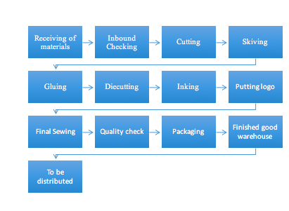

**Dunlop**

Dunlop Slazenger Philippines located in the Freeport Area of Bataan, province of Mariveles is known for making export quality tennis balls that are used for tournaments for 40 years and now it is known as Dunlop International. The process in making these tennis balls are as follows: 1) Chemical Weighing. This process is needed to provide accurate measurements of the chemicals. The weight also depends it doesn???t have specific measurements. 2) Rubber Weighing. 3) Compounding. This process is where the mixing of rubber happens. They use Oven mill machine. 4) Extrusion. The pellets are being put through the forming machine to form, form sheets 5) Deflashing machine. 6) Half shell. 7) the use core molding machine. It???s a machine which grinds the surface of the ball to ensure that it is smooth and can not be easily removed. 8) Covering. This process is the core being covered with cloth but it is still a raw product which leads us to the last step, 9) Final Curing. This process is where they steam the tennis balls to flatten the sides and for the mold marks not to be noticed. Then its being dried. 10) Cleaning, 11) Inspection, 12) Stamping of the logo, 13) Canning and 14) Sleeving. For the cloth preparation these are the following process: 1) Spreading. The process where the they put the adhesive 2) Cloth dipping. They brush coat the cloth. 3) Cloth Clicking. This is where they get the shape of the tennis ball.

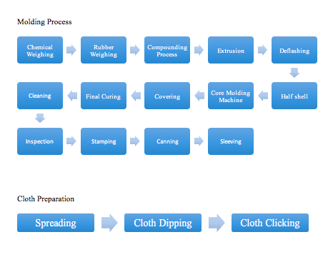

Bibliography

Davies, K. (n.d.). *The Full History of Coach Handbags.* Retrieved November 27, 2017, from http://handbags.lovetoknow.com/The_Full_History_of_Coach_Handbags

(n.d).*Linton, I. Why is it important for businesses to practice quality control?*.  
Retrieved from http://smallbusiness.chron.com/important-businesses-practice-quality-control-69340.html on November 28, 2017.

(n.d.). *Dunlop Slazenger (Philippines), Inc.* Retrieved November 27, 2017, from  
https://www.businesslist.ph/company/182329/dunlop-slazenger-philippines-inc

(2016). *Introduction to Die Cutting*. Retrieved November 27, 2017, from https://personaldiecutting.com/introduction-to-die-cutting/

(n.d.). *MEDTECS INTERNATIONAL CORP. LTD*. Retrieved November 27, 2017, from https://www.philippinecompanies.com/companyprofile/46204/medtecs-international-corp-ltd-

(n.d.). *MEDTECS*. Retrieved November 27, 2017, from http://www.medtecs.com/

(n.d.). *Working at Dunlop International (Philippines), Inc. company profile and information | JobStreet.com Philippines*. Retrieved November 27, 2017, from https://www.jobstreet.com.ph/en/companies/493686-dunlop-international-philippines-inc

(n.d.). *What Are Quality Assurance and Quality Control?* Retrieved November 27, 2017, from http://asq.org/learn-about-quality/quality-assurance-quality-control/overview/overview.html

(n.d.). *why are processes important?* Retrieved November 27, 2017, from http://www.agiledge.com/process/why-are-processes-important

(n.d.). *Using Balances*. Retrieved November 27, 2017, from http://www.chem.science.unideb.hu/Pharm/Notes3.pdf

Kokemuller, N. (n.d.). *Why is Human Resource Selection Process Important?* Retrieved November 27, 2017. from http://smallbusiness.chron.com/human-resource-selection-process-important-14399.html